# pml_assignment

## Loading Data

```r
library(caret)
library(randomForest)
library(rpart)
```

```r
library(rpart.plot)
library(rattle)
trainingset <- read.csv("pml-training.csv", na.strings=c("NA","#DIV/0!", header=TRUE))
testingset <- read.csv("pml-testing.csv", na.strings=c("NA","#DIV/0!", header=TRUE))
summary(trainingset$classe)
```

```
##    A    B    C    D    E
## 5580 3797 3422 3216 3607
```

## Data partition for Cross-validation

The training data is split into two data sets, one for training the model and one for testing the performance of our model. The data is partitioned by the classe variable, which is the varible we will be predicting. The data is split into 60% for training and 40% for testing.

```r
inTrain <- createDataPartition(y=trainingset$classe, p = 0.60, list=FALSE)
training <- trainingset[inTrain,]
testing <- trainingset[-inTrain,]
dim(training); dim(testing)
```

```
## [1] 11776   160
```

```
## [1] 7846  160
```

## Processing of Data

```r
training <- training[,-c(1:7)]
nzv <- nearZeroVar(training, saveMetrics=TRUE)
training <- training[, nzv$nzv==FALSE]
```

There are a lot of variables where most of the values are ‘NA’. Drop variables that have 60% or more of the values as ‘NA’.

```r
training_clean <- training
for(i in 1:length(training)) {
  if( sum( is.na( training[, i] ) ) /nrow(training) >= .6) {
    for(j in 1:length(training_clean)) {
      if( length( grep(names(training[i]), names(training_clean)[j]) ) == 1)  {
        training_clean <- training_clean[ , -j]
      }
    }
  }
}
# Set the new cleaned up dataset back to the old dataset name
training <- training_clean
```

# Transform the testing data dataset

# Get the column names in the training dataset

```r
columns <- colnames(training)
```

# Drop the class variable

```r
col2 <- colnames(training[,-53])
testingset <- testingset[col2]
dim(testingset)
```

```
## [1] 20 52
```

## Prediction with Random Forest

A Random Forest model is built on the training set. Then the results are evaluated on the test set

```r
set.seed(54321)
modFit <- randomForest(classe ~ ., data=training)
prediction <- predict(modFit, testing)
cm <- confusionMatrix(prediction, testing$classe)
print(cm)
```

```
## Confusion Matrix and Statistics
##
##           Reference
## Prediction    A    B    C    D    E
##          A 2229    7    0    0    0
##          B    3 1510   10    0    0
##          C    0    1 1353   18    6
##          D    0    0    5 1267    7
##          E    0    0    0    1 1429
##
## Overall Statistics
##
##                Accuracy : 0.9926
##                  95% CI : (0.9905, 0.9944)
##     No Information Rate : 0.2845
##     P-Value [Acc > NIR] : < 2.2e-16
##
##                   Kappa : 0.9906
##  Mcnemar's Test P-Value : NA
##
## Statistics by Class:
##
##                      Class: A Class: B Class: C Class: D Class: E
## Sensitivity            0.9987   0.9947   0.9890   0.9852   0.9910
## Specificity            0.9988   0.9979   0.9961   0.9982   0.9998
## Pos Pred Value         0.9969   0.9915   0.9819   0.9906   0.9993
## Neg Pred Value         0.9995   0.9987   0.9977   0.9971   0.9980
## Prevalence             0.2845   0.1935   0.1744   0.1639   0.1838
## Detection Rate         0.2841   0.1925   0.1724   0.1615   0.1821
## Detection Prevalence   0.2850   0.1941   0.1756   0.1630   0.1823
## Balanced Accuracy      0.9987   0.9963   0.9926   0.9917   0.9954
```

```r
overall.accuracy <- round(cm$overall['Accuracy'] * 100, 2)
sam.err <- round(1 - cm$overall['Accuracy'],2)
print(c(overall.accuracy,sam.err))
```

```
## Accuracy Accuracy
##    99.26     0.01
```

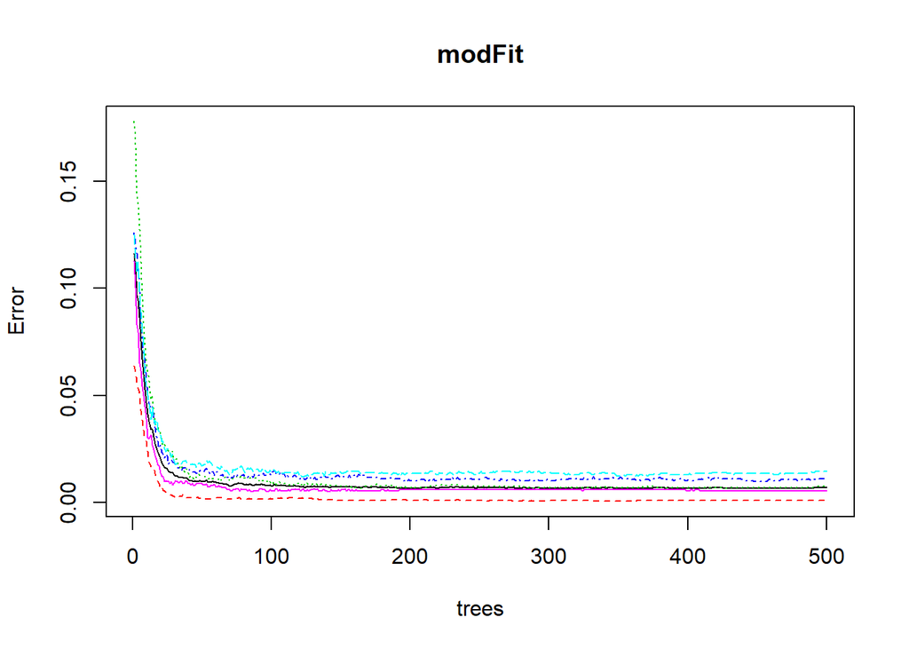

```r
plot(modFit)
```

```r
set.seed(54321)
modFit2 <- rpart(classe ~ ., data=training, method="class")
prediction2 <- predict(modFit2, testing, type="class")
cm2 <- confusionMatrix(prediction2, testing$classe)
print(cm2)
```

```
## Confusion Matrix and Statistics
##
##           Reference
## Prediction    A    B    C    D    E
##          A 2031  304   86  207   71
##          B   65  892  130   47  113
##          C   47  128 1032  210  174
##          D   50  124   83  705   68
##          E   39   70   37  117 1016
##
## Overall Statistics
##
##                Accuracy : 0.7234
##                  95% CI : (0.7134, 0.7333)
##     No Information Rate : 0.2845
##     P-Value [Acc > NIR] : < 2.2e-16
##
##                   Kappa : 0.6475
##  Mcnemar's Test P-Value : < 2.2e-16
##
## Statistics by Class:
##
##                      Class: A Class: B Class: C Class: D Class: E
## Sensitivity            0.9099   0.5876   0.7544  0.54821   0.7046
## Specificity            0.8810   0.9439   0.9137  0.95046   0.9589
## Pos Pred Value         0.7525   0.7153   0.6486  0.68447   0.7944
## Neg Pred Value         0.9609   0.9051   0.9463  0.91476   0.9351
## Prevalence             0.2845   0.1935   0.1744  0.16391   0.1838
## Detection Rate         0.2589   0.1137   0.1315  0.08985   0.1295
## Detection Prevalence   0.3440   0.1589   0.2028  0.13128   0.1630
## Balanced Accuracy      0.8955   0.7658   0.8340  0.74933   0.8318
```

```r
overall.accuracy2 <- round(cm2$overall['Accuracy'] * 100, 2)
sam.err2 <- round(1 - cm2$overall['Accuracy'],2)
print(c(overall.accuracy2,sam.err2))
```

```
## Accuracy Accuracy
##    72.34     0.28
```

## Plot the classification tree model

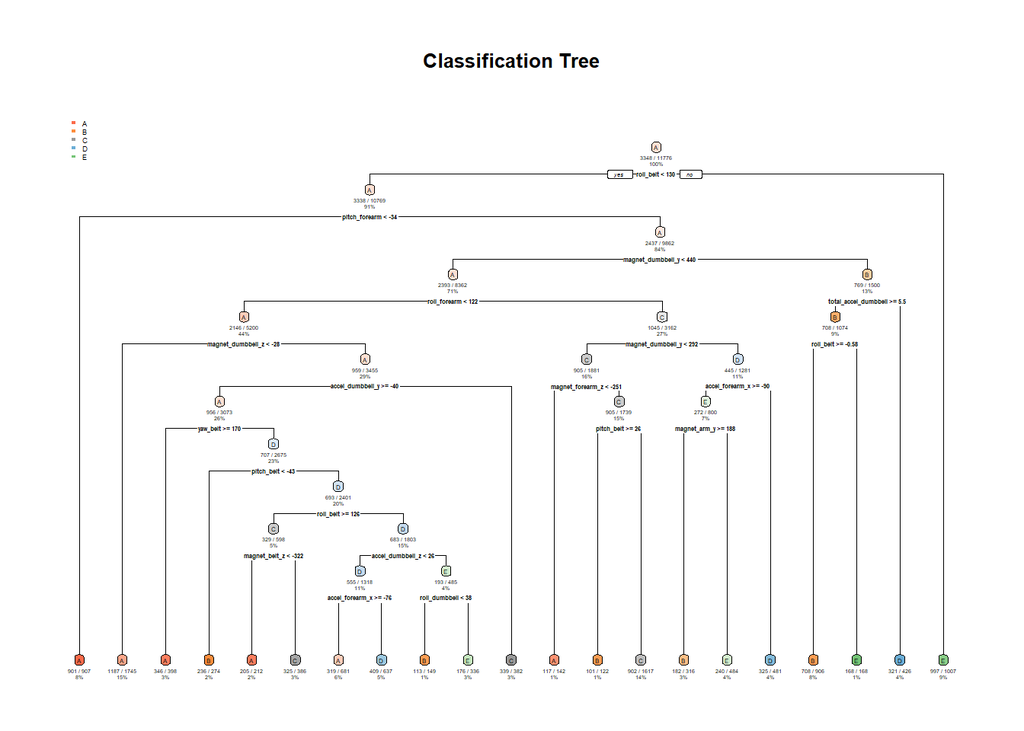

```r
rpart.plot(modFit2, main="Classification Tree", extra=102, under=TRUE, faclen=0)
```

Overall Accuracy of Random Forest model is higher than decision tree model. So we will use the Random Forest model to make the predictions on the test data.

```r
final_prediction <- predict(modFit, testingset, type="class")
print(final_prediction)
```

```
##  1  2  3  4  5  6  7  8  9 10 11 12 13 14 15 16 17 18 19 20
##  B  A  B  A  A  E  D  B  A  A  B  C  B  A  E  E  A  B  B  B
## Levels: A B C D E
```